# Portfolio Project

Albert Swingler

1. Introduction: I choose this topic because politics is an important thing in our “democracy”. It is especially important to keep track of what polititians say versus what they do in this day and age where it seems like most of them can lie and get away with anything.
2. Data set. My data is from FiveThirtyEight and it has information about which congress peoples votes aligned with Trump predictions for how they will vote in the future. https://projects.fivethirtyeight.com/congress-trump-score/
3. Source: This data is from FiveThirtyEight which is a website that gathers data on sports, politics, and economics. This site is widely recognized as being reliable and used as a source by publications like the New York Times.
4. Variables: congress: wheather they are in the 115th congress session (1/17 to 1/19) or 116th (1/19 to 1/21). 0 if both.

chamber: if they are in the house or the senate

bioguide: government given alphanumeric ID for each legislator

votes: How many bills they have voted on total.

agree_pct: The percentage of time they vote for Trumps position

predicted_agree: How likely a congressperson is expected to vote with trump based on Trumps 2016 margin

net_trump_vote: Trump’s share of votes in the 2016 election in the member’s state or district minus Clinton’s

```r
library("tidyverse")
library("dplyr")
library("ggplot2")
library("knitr")

averages <- read_csv("https://raw.githubusercontent.com/introdsci/DataScience-aswingler1/master/averages.csv")
vote_predictions <- read_csv("https://raw.githubusercontent.com/introdsci/DataScience-aswingler1/master/vote_predictions.csv")
```

Imported the libraries I’m using and the CSVs

5. Modifications to clean up data:

```r
colnames(averages)[colnames(averages) == "votes"] <- "num_votes"

averages$party <- substr(averages$party, 0, 1)
```

Renaming vote columns in the tables.

Truncated the party observations so its only the first letter. Previously some of them had the full spelling.

Added the generation number 3 if they are third generation or higher.

```r
politician <- tibble(last_name=averages$last_name, congress=averages$congress, chamber=averages$chamber, num_votes=averages$num_votes, state=averages$state, district=averages$district, party=averages$party)

politician <- add_column(politician, generation=3)



bill <-tibble(bill_id=vote_predictions$bill_id, roll_id=vote_predictions$roll_id, congress=vote_predictions$congress, chamber=vote_predictions$chamber, voted_at=vote_predictions$voted_at)
```

Creating the dataframes. I seperated out the polititians and the bills.

6. Data summary with visulizations:

```r
averages$state <- as.factor(averages$state)
levels(averages$state)
```

```
 [1] "AK" "AL" "AR" "AZ" "CA" "CO" "CT" "DE" "FL" "GA" "HI" "IA" "ID" "IL" "IN" "KS" "KY" "LA" "MA" "MD" "ME" "MI" "MN" "MO" "MS"
[26] "MT" "NC" "ND" "NE" "NH" "NJ" "NM" "NV" "NY" "OH" "OK" "OR" "PA" "RI" "SC" "SD" "TN" "TX" "UT" "VA" "VT" "WA" "WI" "WV" "WY"
```

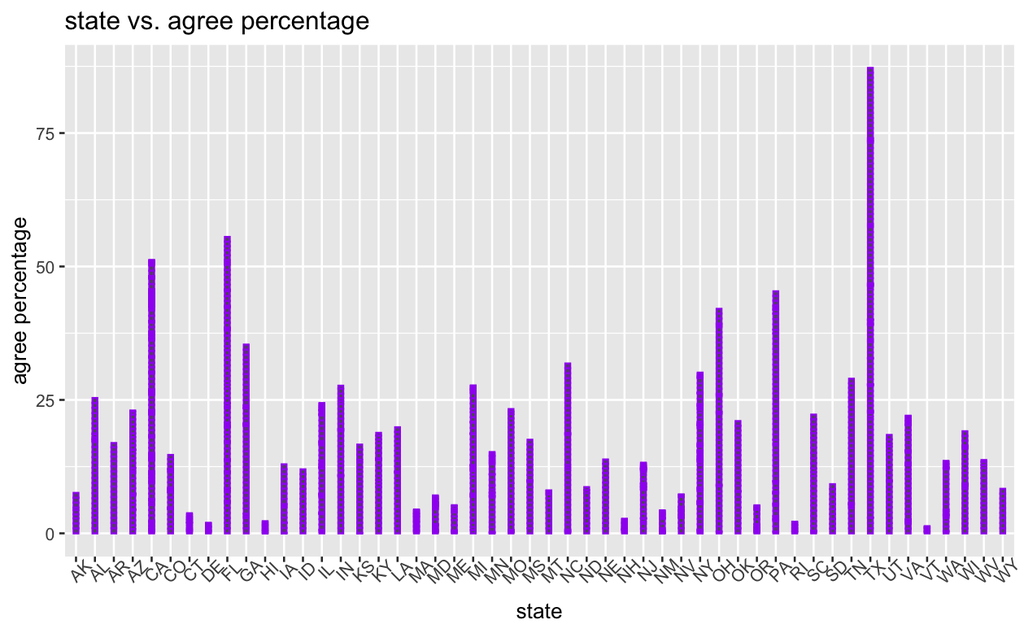

```r
#averages$agree_pct <- as.factor(averages$agree_pct)

avg_pct_vote_by_state <- ggplot(averages, aes(state, agree_pct)) + geom_bar(stat="identity", width=.25, color="purple") +  theme(axis.text.x = element_text(angle = 45)) + ggtitle("state vs. agree percentage") + ylab("agree percentage")
avg_pct_vote_by_state
```

Visualizing how likely the congress members as a whole from each state are to vote with trump

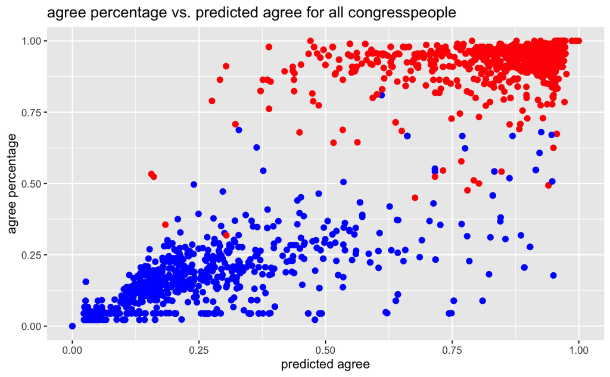

```r
agree_vs_predicted_agree <- ggplot(averages, aes(predicted_agree, agree_pct)) + geom_point(size=2, shape=19, col = ifelse(politician$party == "R", 'red', 'blue')) + ylab("agree percentage") + xlab("predicted agree") + ggtitle("agree percentage vs. predicted agree for all congresspeople")


agree_vs_predicted_agree
```

Visualizing the agree percentage with the predicted agree. As you can see, most congress members voted how they were predicted but there are a few outlers. Several in the bottom right of the graph were predicted to agree over 75% of the time but ended up only agreeing less than 25% of the time. Repubicans are Red and Democrats are blue. Need to get Independants showing as a third color but currently they’re showing as blue. Fortunatly there are not very many of them.